# Chronic Kidney Disease

Frantisek Urban

December 2019

## Pochopenie cieľa

Cieľom tejto práce je vytvoriť podporný sýstém pri rozhodovaní lekárov(odborníkov) o zdravotnom stave pacienta. Prostredníctvom klasifikácie budem predpovedať či pacient je alebo nie je chorý. Keďže ide o vytvorenie systému, nie vždy je to 100% rozhodnutie záleži to na mnohých faktoroch, ktoré do daného procesu vstupujú. Hlavnou myšlienkou resp. cieľom tejto práce je zistiť (klasifikovať) či daná osoba trpí ochorením alebo nie.

[figure not shown]

## Pochopenie dát

V mojej analýze som sa zameral na chronické ochorenie obličiek, ktoré patrí medzi jedno z vážnych ochorení, často aj smrteľných. Ochorenie má vo vačšine prípadov rovnaký priebeh postupné zlyhávanie funkcie a následne úplné zlyhanie. Potom je pacient odkázaný už len na samotnú dialýzu alebo taktiež jednou z možností je aj transplantácia. Tomuto sa ale dá vo väčšine prípadov predísť a to kontrolami tzv. skríningom.

## Dataset

Pracovať budem s datasetom zameraným na toto ochorenie a to [Chronic Kidney Disease Data Set](https://archive.ics.uci.edu/ml/datasets/Chronic_Kidney_Disease#), ktorý som stiahol z [UCI Machine learning reposity](https://archive.ics.uci.edu/ml/index.php). Myslím si, že je to vhodný dataset vzhľadom k množstvu atribútov, ktoré obsahuje či už nominálne alebo numerické. Údaje, ktoré dataset obsahuje nie sú spracované a teda obsahujú aj chýbajúce hodnoty, ktoré bude treba eliminovať alebo doplniť vhodnými metódami.

#### Informacie o samotnom datasete

Source: Dr.P.Soundarapandian.M.D.,D.M (Senior Consultant Nephrologist), Apollo Hospitals, Managiri, Madurai Main Road, Karaikudi, Tamilnadu, India.

Creator: L.Jerlin Rubini(Research Scholar) Alagappa University, EmailId :jel.jerlin ‘@’ gmail.com ContactNo :+91-9597231281

Guided by: Dr.P.Eswaran Assistant Professor, Department of Computer Science and Engineering, Alagappa University, Karaikudi, Tamilnadu, India. Emailid:eswaranperumal ‘@’ gmail.com

## Atribúty

#### Popis atribútov

Ako som už spomínal dataset obsahuje 25 atribútov rozdelených na dve skupiny a to numerické a nominálne.

#### Tabuľka rozdelenia atribútov a hodnôt, ktoré môžu nadobúdať

| Atribút | Označenie | Typ | hodnoty |
| --- | --- | --- | --- |
| **Age** | age | numerical | years |
| **Blood Pressure** | bp | numerical | mm/Hg |
| **Specific Gravity** | sg | nominal | 1.005,1.010,1.015,1.020,1.025 |
| **Albumin** | al | nominal | 0,1,2,3,4,5 |
| **Sugar** | su | nominal | 0,1,2,3,4,5 |
| **Red Blood Cells** | rbc | nominal | normal,abnormal |
| **Pus Cell** | pc | nominal | normal,abnormal |
| **Pus Cell Clumps** | pcc | nominal | present, notpresent |
| **Bacteria** | ba | nominal | present, notpresent |
| **Blood Glucose Random** | bgr | numerical | mgs/dl |
| **Blood Urea** | bu | numerical | mgs/dl |
| **Serum Creatine** | sc | numerical | mgs/dl |
| **Sodium** | sod | numerical | mEq/L |
| **Potasium** | pot | numerical | mEq/L |
| **Hemoglobin** | hemo | numerical | gms |
| **Packet Cell Volume** | pcv | numerical |  |
| **White Blood Cell Count** | wc | numerical | cells/cumm |
| **Red Blood Cell Count** | rc | numerical | milions/cmm |
| **Hypertension** | htn | nominal | yes,no |
| **Diabetes** | dm | nominal | yes,no |
| **Coronary Artery Disease** | cad | nominal | yes,no |
| **Appetite** | appet | nominal | good,poor |
| **Pedal Edema** | pe | nominal | yes,no |
| **Anemia** | ane | nominal | yes,no |
| **Class** | class | nominal | ckd,notckd |

## Načítanie dát

```r
ckd = read.csv(file = "/Users/frantisekurban/Desktop/3KOLA/PA/chronic_kidney_disease.arff", header = FALSE, fill = TRUE, comment.char = "@")
```

### Počet hodnot a atribútov datasetu

```r
dim(ckd)
```

```
## [1] 400  25
```

Tento stav je pôvodný teda obsahuje aj ? resp.(“NA”) hodnoty

### Pomenovanie atribútov

Kvôli lepšiemu orientovaniu sa medzi atribútmi ako aj samotným pochopením dát je dobre si atribúty v načítanom datasete pomenovať:

```r
colnames(ckd) = c("age","bp","sg","al","su","rbc","pc","pcc","ba",
                  "bgr","bu","sc","sod","pot","hemo","pcv","wc",
                  "rc","htn","dm","cad","appet","pe","ane","class")
```

```r
str(ckd)
```

```
## 'data.frame':    400 obs. of  25 variables:
##  $ age  : Factor w/ 77 levels "?","11","12",..: 38 62 54 38 42 52 60 13 43 44 ...
##  $ bp   : Factor w/ 11 levels "?","100","110",..: 10 7 10 9 10 11 9 1 2 11 ...
##  $ sg   : Factor w/ 6 levels "?","1.005","1.010",..: 5 5 3 2 3 4 3 4 4 5 ...
##  $ al   : Factor w/ 7 levels "?","0","1","2",..: 3 6 4 6 4 5 2 4 5 4 ...
##  $ su   : Factor w/ 7 levels "?","0","1","2",..: 2 2 5 2 2 2 2 6 2 2 ...
##  $ rbc  : Factor w/ 3 levels "?","abnormal",..: 1 1 3 3 3 1 1 3 3 2 ...
##  $ pc   : Factor w/ 3 levels "?","abnormal",..: 3 3 3 2 3 1 3 2 2 2 ...
##  $ pcc  : Factor w/ 3 levels "?","notpresent",..: 2 2 2 3 2 2 2 2 3 3 ...
##  $ ba   : Factor w/ 3 levels "?","notpresent",..: 2 2 2 2 2 2 2 2 2 2 ...
##  $ bgr  : Factor w/ 147 levels "?","100","101",..: 23 1 116 19 8 123 2 114 37 122 ...
##  $ bu   : Factor w/ 119 levels "?","1.5","10",..: 65 34 83 86 53 52 84 59 89 6 ...
##  $ sc   : Factor w/ 87 levels "?","0.4","0.5",..: 11 6 17 57 13 10 50 10 18 78 ...
##  $ sod  : Factor w/ 35 levels "?","104","111",..: 1 1 1 3 1 27 2 1 1 5 ...
##  $ pot  : Factor w/ 43 levels "?","2.5","2.7",..: 1 1 1 2 1 7 17 1 1 12 ...
##  $ hemo : Factor w/ 119 levels "?","10.0","10.1",..: 59 15 116 14 18 25 27 27 10 115 ...
##  $ pcv  : Factor w/ 44 levels "\t43","?","14",..: 33 27 20 21 24 28 25 33 22 18 ...
##  $ wc   : Factor w/ 93 levels "\t?","\t6200",..: 74 58 72 64 70 74 4 66 90 20 ...
##  $ rc   : Factor w/ 50 levels "\t?","?","2.1",..: 36 2 2 21 29 27 2 33 23 19 ...
##  $ htn  : Factor w/ 3 levels "?","no","yes": 3 2 2 3 2 3 2 2 3 3 ...
##  $ dm   : Factor w/ 6 levels "\tno","\tyes",..: 6 5 6 5 5 6 5 6 6 6 ...
##  $ cad  : Factor w/ 3 levels "?","no","yes": 2 2 2 2 2 2 2 2 2 2 ...
##  $ appet: Factor w/ 3 levels "?","good","poor": 2 2 3 3 2 2 2 2 2 3 ...
##  $ pe   : Factor w/ 3 levels "?","no","yes": 2 2 2 3 2 3 2 3 2 2 ...
##  $ ane  : Factor w/ 3 levels "?","no","yes": 2 2 3 3 2 2 2 2 3 3 ...
##  $ class: Factor w/ 3 levels "ckd","ckd\t",..: 1 1 1 1 1 1 1 1 1 1 ...
```

Na základe tohto príkazu môžeme vidieť stav samotných atribútov či už ide o hodnoty daného atribútu alebo typ atribútu. Ako vidíme tak všetky atribúty sú typu factor a to je potrebné zmeniť ak chceme dáta analyzovať. Jednotlivé atribúty si upravíme na základe informácií o atribútoch kde to máme presne definované. Ešte predtým je ale potrebné eliminovať znaky typu “?”

```r
ckd[ckd == "?"] <- NA
```

```r
#pretypovanie numerických atribútov
ckd$age = as.numeric(as.character(ckd$age))
ckd$bp = as.numeric(as.character(ckd$bp))
ckd$bgr = as.numeric(as.character(ckd$bgr))
ckd$bu= as.numeric(as.character(ckd$bu))
ckd$sc = as.numeric(as.character(ckd$sc))
ckd$sod = as.numeric(as.character(ckd$sod))
ckd$pot = as.numeric(as.character(ckd$pot))
ckd$hemo = as.numeric(as.character(ckd$hemo))
ckd$pcv = as.numeric(as.character(ckd$pcv))
ckd$wc = as.numeric(as.character(ckd$wc))
ckd$rc = as.numeric(as.character(ckd$rc))
```

```r
#eliminácia chyných levels v atribútoch
ckd$sg = droplevels(ckd$sg)
ckd$al = droplevels(ckd$al)
ckd$su = droplevels(ckd$su)
ckd$rbc = droplevels(ckd$rbc)
ckd$pc = droplevels(ckd$pc)
ckd$pcc = droplevels(ckd$pcc)
ckd$ba = droplevels(ckd$ba)
ckd$htn = droplevels(ckd$htn)
ckd$dm = droplevels(ckd$dm)
ckd$cad = droplevels(ckd$cad)
ckd$appet = droplevels(ckd$appet)
ckd$ane = droplevels(ckd$ane)
ckd$class = droplevels(ckd$class)
```

tu možeme následne vidieť pretypovanie atribútov a taktiež elimináciu “?”(hodnoty) -> NA (hodnotu)

```r
str(ckd)
```

```
## 'data.frame':    400 obs. of  25 variables:
##  $ age  : num  48 7 62 48 51 60 68 24 52 53 ...
##  $ bp   : num  80 50 80 70 80 90 70 NA 100 90 ...
##  $ sg   : Factor w/ 5 levels "1.005","1.010",..: 4 4 2 1 2 3 2 3 3 4 ...
##  $ al   : Factor w/ 6 levels "0","1","2","3",..: 2 5 3 5 3 4 1 3 4 3 ...
##  $ su   : Factor w/ 6 levels "0","1","2","3",..: 1 1 4 1 1 1 1 5 1 1 ...
##  $ rbc  : Factor w/ 2 levels "abnormal","normal": NA NA 2 2 2 NA NA 2 2 1 ...
##  $ pc   : Factor w/ 2 levels "abnormal","normal": 2 2 2 1 2 NA 2 1 1 1 ...
##  $ pcc  : Factor w/ 2 levels "notpresent","present": 1 1 1 2 1 1 1 1 2 2 ...
##  $ ba   : Factor w/ 2 levels "notpresent","present": 1 1 1 1 1 1 1 1 1 1 ...
##  $ bgr  : num  121 NA 423 117 106 74 100 410 138 70 ...
##  $ bu   : num  36 18 53 56 26 25 54 31 60 107 ...
##  $ sc   : num  1.2 0.8 1.8 3.8 1.4 1.1 24 1.1 1.9 7.2 ...
##  $ sod  : num  NA NA NA 111 NA 142 104 NA NA 114 ...
##  $ pot  : num  NA NA NA 2.5 NA 3.2 4 NA NA 3.7 ...
##  $ hemo : num  15.4 11.3 9.6 11.2 11.6 12.2 12.4 12.4 10.8 9.5 ...
##  $ pcv  : num  44 38 31 32 35 39 36 44 33 29 ...
##  $ wc   : num  7800 6000 7500 6700 7300 7800 NA 6900 9600 12100 ...
##  $ rc   : num  5.2 NA NA 3.9 4.6 4.4 NA 5 4 3.7 ...
##  $ htn  : Factor w/ 2 levels "no","yes": 2 1 1 2 1 2 1 1 2 2 ...
##  $ dm   : Factor w/ 5 levels "\tno","\tyes",..: 5 4 5 4 4 5 4 5 5 5 ...
##  $ cad  : Factor w/ 2 levels "no","yes": 1 1 1 1 1 1 1 1 1 1 ...
##  $ appet: Factor w/ 2 levels "good","poor": 1 1 2 2 1 1 1 1 1 2 ...
##  $ pe   : Factor w/ 3 levels "?","no","yes": 2 2 2 3 2 3 2 3 2 2 ...
##  $ ane  : Factor w/ 2 levels "no","yes": 1 1 2 2 1 1 1 1 2 2 ...
##  $ class: Factor w/ 3 levels "ckd","ckd\t",..: 1 1 1 1 1 1 1 1 1 1 ...
```

```r
#vzorový výpis hodnôt atribútov
ckd[1:3,]
```

```
##   age bp    sg al su    rbc     pc        pcc         ba bgr bu  sc sod
## 1  48 80 1.020  1  0   <NA> normal notpresent notpresent 121 36 1.2  NA
## 2   7 50 1.020  4  0   <NA> normal notpresent notpresent  NA 18 0.8  NA
## 3  62 80 1.010  2  3 normal normal notpresent notpresent 423 53 1.8  NA
##   pot hemo pcv   wc  rc htn  dm cad appet pe ane class
## 1  NA 15.4  44 7800 5.2 yes yes  no  good no  no   ckd
## 2  NA 11.3  38 6000  NA  no  no  no  good no  no   ckd
## 3  NA  9.6  31 7500  NA  no yes  no  poor no yes   ckd
```

### Sumárny výpis jednotlivých atribútov

- Numerické atribúty zobrazenie Min,Max hodnôt, taktiež aj Median, 1st Qu, 3rd Qu a počet NA hodnôt, ktoré daný atribút obsahuje.

```r
summary(ckd)
```

```
##       age              bp             sg         al         su
##  Min.   : 2.00   Min.   : 50.00   1.005:  7   0   :199   0   :290
##  1st Qu.:42.00   1st Qu.: 70.00   1.010: 84   1   : 44   1   : 13
##  Median :55.00   Median : 80.00   1.015: 75   2   : 43   2   : 18
##  Mean   :51.48   Mean   : 76.47   1.020:106   3   : 43   3   : 14
##  3rd Qu.:64.50   3rd Qu.: 80.00   1.025: 81   4   : 24   4   : 13
##  Max.   :90.00   Max.   :180.00   NA's : 47   5   :  1   5   :  3
##  NA's   :9       NA's   :12                   NA's: 46   NA's: 49
##        rbc             pc              pcc               ba
##  abnormal: 47   abnormal: 76   notpresent:354   notpresent:374
##  normal  :201   normal  :259   present   : 42   present   : 22
##  NA's    :152   NA's    : 65   NA's      :  4   NA's      :  4
##
##
##
##
##       bgr            bu               sc              sod
##  Min.   : 22   Min.   :  1.50   Min.   : 0.400   Min.   :  4.5
##  1st Qu.: 99   1st Qu.: 27.00   1st Qu.: 0.900   1st Qu.:135.0
##  Median :121   Median : 42.00   Median : 1.300   Median :138.0
##  Mean   :148   Mean   : 57.43   Mean   : 3.072   Mean   :137.5
##  3rd Qu.:163   3rd Qu.: 66.00   3rd Qu.: 2.800   3rd Qu.:142.0
##  Max.   :490   Max.   :391.00   Max.   :76.000   Max.   :163.0
##  NA's   :44    NA's   :19       NA's   :17       NA's   :87
##       pot              hemo            pcv              wc
##  Min.   : 2.500   Min.   : 3.10   Min.   : 9.00   Min.   : 2200
##  1st Qu.: 3.800   1st Qu.:10.30   1st Qu.:32.00   1st Qu.: 6500
##  Median : 4.400   Median :12.65   Median :40.00   Median : 8000
##  Mean   : 4.627   Mean   :12.53   Mean   :38.88   Mean   : 8406
##  3rd Qu.: 4.900   3rd Qu.:15.00   3rd Qu.:45.00   3rd Qu.: 9800
##  Max.   :47.000   Max.   :17.80   Max.   :54.00   Max.   :26400
##  NA's   :88       NA's   :52      NA's   :71      NA's   :106
##        rc          htn         dm         cad       appet        pe
##  Min.   :2.100   no  :251   \tno :  2   no  :364   good:317   ?   :  0
##  1st Qu.:3.900   yes :147   \tyes:  2   yes : 34   poor: 82   no  :323
##  Median :4.800   NA's:  2    yes :  1   NA's:  2   NA's:  1   yes : 76
##  Mean   :4.707              no   :259                         NA's:  1
##  3rd Qu.:5.400              yes  :134
##  Max.   :8.000              NA's :  2
##  NA's   :131
##    ane         class
##  no  :339   ckd   :248
##  yes : 60   ckd\t :  2
##  NA's:  1   notckd:150
##
##
##
##
```

### Chýbajúce hodnoty

- pre lepšie pochopenie počtu chýbajúcich hodnôt v danom atribúte som to percentuálne vyjadril:

```r
apply(ckd,2,function(i) {(sum(is.na(i))/nrow(ckd))*100})
```

```
##   age    bp    sg    al    su   rbc    pc   pcc    ba   bgr    bu    sc
##  2.25  3.00 11.75 11.50 12.25 38.00 16.25  1.00  1.00 11.00  4.75  4.25
##   sod   pot  hemo   pcv    wc    rc   htn    dm   cad appet    pe   ane
## 21.75 22.00 13.00 17.75 26.50 32.75  0.50  0.50  0.50  0.25  0.25  0.25
## class
##  0.00
```

na základe toho by sa dali eliminovať atribúty v ktorých chýba určité percento údajov, ale tomu sa budeme venovať v časti predspracovanie.

## Vizualizácia atribútov

#### Numerické atribúty

- Na vizualizáciu numerických atribútov som použil histogram

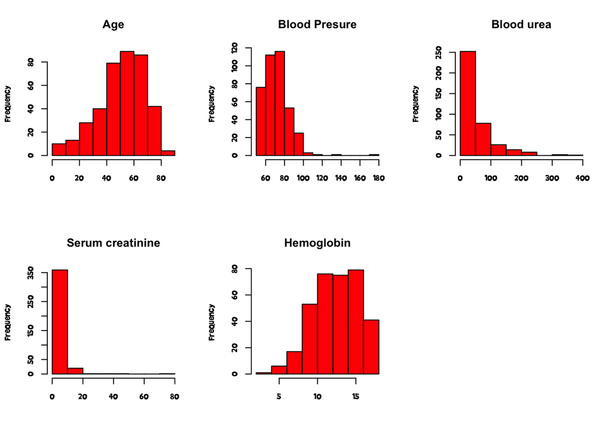

```r
par(mfrow=c(2,3))
hist(ckd$age, main = "Age", xlab="", col = "red")
hist(ckd$bp, main = "Blood Presure", xlab="", col = "red")
hist(ckd$bu, main = "Blood urea", xlab="", col = "red")
hist(ckd$sc, main = "Serum creatinine", xlab="", col = "red")
hist(ckd$hemo, main = "Hemoglobin", xlab="", col = "red")
```

#### Nominálne atribúty

- Pri nominálnych atribútoch som na vykreslenie grafov použil barplot

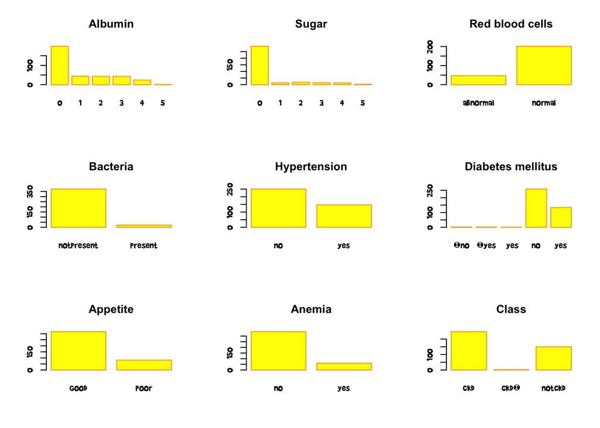

```r
par(mfrow=c(3,3))
barplot(table(ckd$al), main = "Albumin", border="orange",col="yellow")
barplot(table(ckd$su), main = "Sugar", border="orange",col="yellow")
barplot(table(ckd$rbc), main = "Red blood cells", border="orange",col="yellow")
barplot(table(ckd$ba), main = "Bacteria", border="orange",col="yellow")
barplot(table(ckd$htn), main = "Hypertension", border="orange",col="yellow")
barplot(table(ckd$dm), main = "Diabetes mellitus", border="orange",col="yellow")
barplot(table(ckd$appet), main = "Appetite", border="orange",col="yellow")
barplot(table(ckd$ane), main = "Anemia", border="orange",col="yellow")
barplot(table(ckd$class), main = "Class", border="orange",col="yellow")
```

#### Histogram (age by class)

- Histogram zobrazujúci vek a chorobnosť pacientov

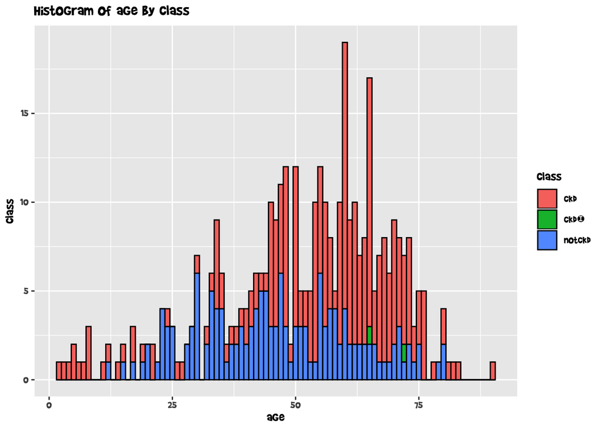

```r
library("ggplot2")
ggplot(ckd) + aes(x=as.numeric(age), group=class , fill = class) +
  ggtitle("Histogram of age by class") + xlab("age") + ylab("class") + geom_histogram(binwidth = 1, color='black')
```

- Ako na tomto grafe môžeme vidieť najväčšie percento chorobnosti je po veku 40. *Z grafu možeme taktiež vidieť, že v tomto datasete je viac pacientov, ktorý trpia ochrorením ako tých zdravých.(ckp = chorý, notckp = zdravý)

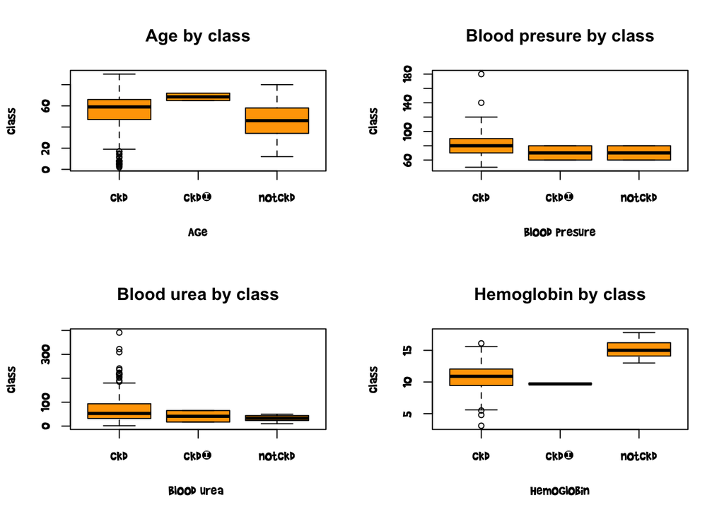

```r
par(mfrow=c(2,2))
boxplot (age~class, data =ckd, main = "Age by class", xlab = "Age", ylab = "class", col = "orange")
boxplot (bp~class, data =ckd, main = "Blood presure by class", xlab = "Blood presure", ylab = "class", col = "orange")
boxplot (bu~class, data =ckd, main = "Blood urea by class", xlab = "Blood urea ", ylab = "class", col = "orange")
boxplot (hemo~class, data =ckd, main = "Hemoglobin by class", xlab = "Hemoglobin", ylab = "class", col = "orange")
```

- Korelácia rieši(meria) aký vzťah majú medzi sebou dva atribúty. *Ak sú atribúty vysoko korelovavé tak nastáva problém, ktorý treba vyriešiť

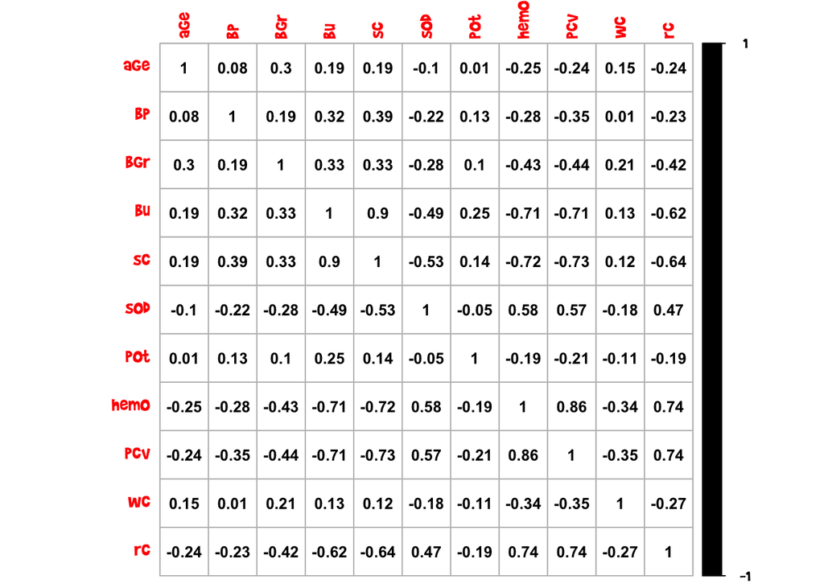

```r
library(corrplot)
ckd2 = na.omit(ckd)
correlat = cor(ckd2[c(1,2,10:18)])
corrplot(correlat, col = "black",number.cex = .8, method = "number")
```

Corrplot nám vyjadril korelácie medzi atribútmi z ktorých sme mohli vyčítať, že medzi niektorými atribútmi nám vznikli korelácie väčšie ako 0.8: * sc / bu = 0.9 * pcv / hemo = 0.86 na základe toho som dospel k záveru, že je potrebné tieto atribúty vymazať.

## Predspracovanie

#### Vymazanie nepotrebných hodnôt

```r
ckd_drop = ckd2
ckd_drop$dm = droplevels(ckd_drop$dm)
ckd_drop$pe = droplevels(ckd_drop$pe)
ckd_drop$class = droplevels(ckd_drop$class)
ckd.model = ckd_drop
#vymazanie hodnôt
ckd.model$sc = NULL
ckd.model$bu = NULL
ckd.model$pcv = NULL
ckd.model$hemo = NULL
summary(ckd.model)
```

```
##       age              bp             sg     al      su
##  Min.   : 6.00   Min.   : 50.00   1.005: 3   0:116   0:140
##  1st Qu.:39.25   1st Qu.: 60.00   1.010:23   1:  3   1:  6
##  Median :50.50   Median : 80.00   1.015:10   2:  9   2:  6
##  Mean   :49.56   Mean   : 74.05   1.020:61   3: 15   3:  3
##  3rd Qu.:60.00   3rd Qu.: 80.00   1.025:61   4: 15   4:  2
##  Max.   :83.00   Max.   :110.00              5:  0   5:  1
##        rbc             pc              pcc               ba
##  abnormal: 18   abnormal: 29   notpresent:144   notpresent:146
##  normal  :140   normal  :129   present   : 14   present   : 12
##
##
##
##
##       bgr             sod             pot               wc
##  Min.   : 70.0   Min.   :111.0   Min.   : 2.500   Min.   : 3800
##  1st Qu.: 97.0   1st Qu.:135.0   1st Qu.: 3.700   1st Qu.: 6525
##  Median :115.5   Median :139.0   Median : 4.500   Median : 7800
##  Mean   :131.3   Mean   :138.8   Mean   : 4.637   Mean   : 8476
##  3rd Qu.:131.8   3rd Qu.:144.0   3rd Qu.: 4.900   3rd Qu.: 9775
##  Max.   :490.0   Max.   :150.0   Max.   :47.000   Max.   :26400
##        rc         htn        dm       cad       appet       pe
##  Min.   :2.100   no :124   no :130   no :147   good:139   no :138
##  1st Qu.:4.500   yes: 34   yes: 28   yes: 11   poor: 19   yes: 20
##  Median :4.950
##  Mean   :4.892
##  3rd Qu.:5.600
##  Max.   :8.000
##   ane         class
##  no :142   ckd   : 43
##  yes: 16   notckd:115
##
##
##
##
```

## Modely

#### Vytvorenie trénovacích a testovacích množín

Pre prácu s modelmi je potrebné vytvoriť trénovaciu množinu. Ja som sa rozhodol vytvoriť trénovacie množiny pre 3 pomery a to 90:10, 80:20, 70:30

```r
library(party)
library(caret)
library(e1071)

set.seed(1234)
#množina v pomere 90:10
ind1<- sample(2, nrow(ckd.model),replace = TRUE, prob = c(0.9,0.1))
train1.data <- ckd.model[ind1 == 1, ]
test1.data <- ckd.model[ind1 == 2, ]

#množina v pomere 90:10
ind2<- sample (2, nrow(ckd.model),replace = TRUE, prob = c(0.8,0.2))
train2.data <- ckd.model[ind2 == 1, ]
test2.data <- ckd.model[ind2 == 2, ]

#množina v pomere 90:10
ind3 <- sample (2, nrow(ckd.model),replace = TRUE, prob = c(0.7,0.3))
train3.data <- ckd.model[ind3 == 1, ]
test3.data <- ckd.model[ind3 == 2, ]
```

## Rozhodovacie stromy

### RS (všeobecnejší prípad)

Tento model som vytvoril z dôvodu aby bolo možné vidieť ako silné sú atribúty v datasete

```
##
##          ckd notckd
##   ckd     34      0
##   notckd   6    100
```

```
##
##   Conditional inference tree with 4 terminal nodes
##
## Response:  class
## Inputs:  dm, sod, ane
## Number of observations:  140
##
## 1) dm == {yes}; criterion = 1, statistic = 83.031
##   2)*  weights = 27
## 1) dm == {no}
##   3) ane == {yes}; criterion = 1, statistic = 56.894
##     4)*  weights = 7
##   3) ane == {no}
##     5) sod <= 136; criterion = 0.997, statistic = 10.903
##       6)*  weights = 24
##     5) sod > 136
##       7)*  weights = 82
```

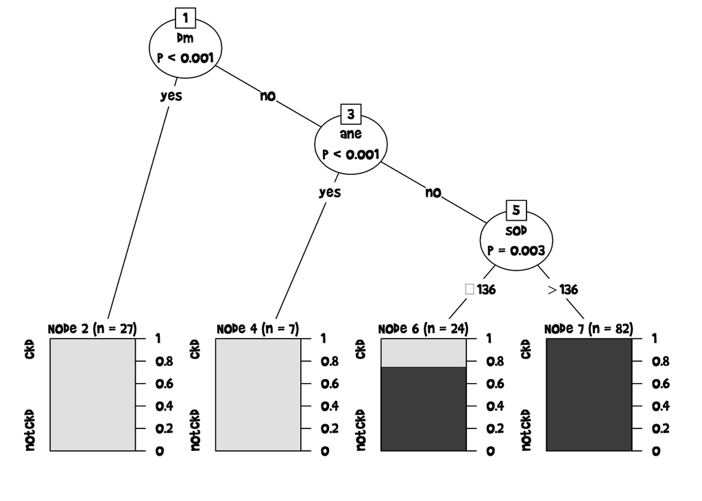

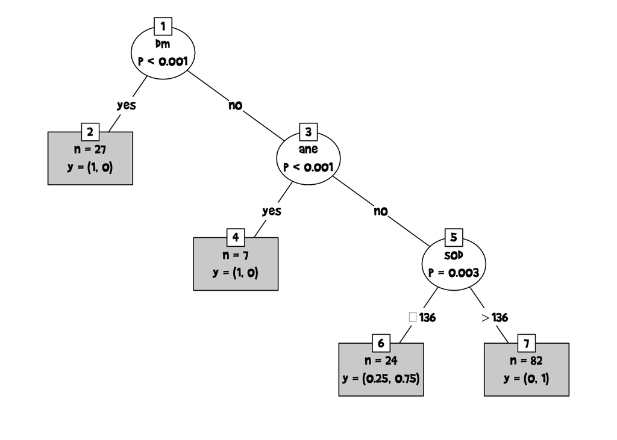

```
## Confusion Matrix and Statistics
##
##
## testPred1 ckd notckd
##    ckd      2      0
##    notckd   1     15
##
##                Accuracy : 0.9444
##                  95% CI : (0.7271, 0.9986)
##     No Information Rate : 0.8333
##     P-Value [Acc > NIR] : 0.1728
##
##                   Kappa : 0.7692
##
##  Mcnemar's Test P-Value : 1.0000
##
##             Sensitivity : 0.6667
##             Specificity : 1.0000
##          Pos Pred Value : 1.0000
##          Neg Pred Value : 0.9375
##              Prevalence : 0.1667
##          Detection Rate : 0.1111
##    Detection Prevalence : 0.1111
##       Balanced Accuracy : 0.8333
##
##        'Positive' Class : ckd
##
```

### RS 90:10

```
##
##          ckd notckd
##   ckd     39      0
##   notckd   1    100
```

```
##
##   Conditional inference tree with 3 terminal nodes
##
## Response:  class
## Inputs:  age, bp, sg, al, su, rbc, pc, pcc, ba, bgr, sod, pot, wc, rc, htn, dm, cad, appet, pe, ane
## Number of observations:  140
##
## 1) al == {1, 2, 3, 4}; criterion = 1, statistic = 134.183
##   2)*  weights = 39
## 1) al == {0}
##   3) sg == {1.005, 1.025}; criterion = 1, statistic = 100
##     4)*  weights = 50
##   3) sg == {1.020}
##     5)*  weights = 51
```

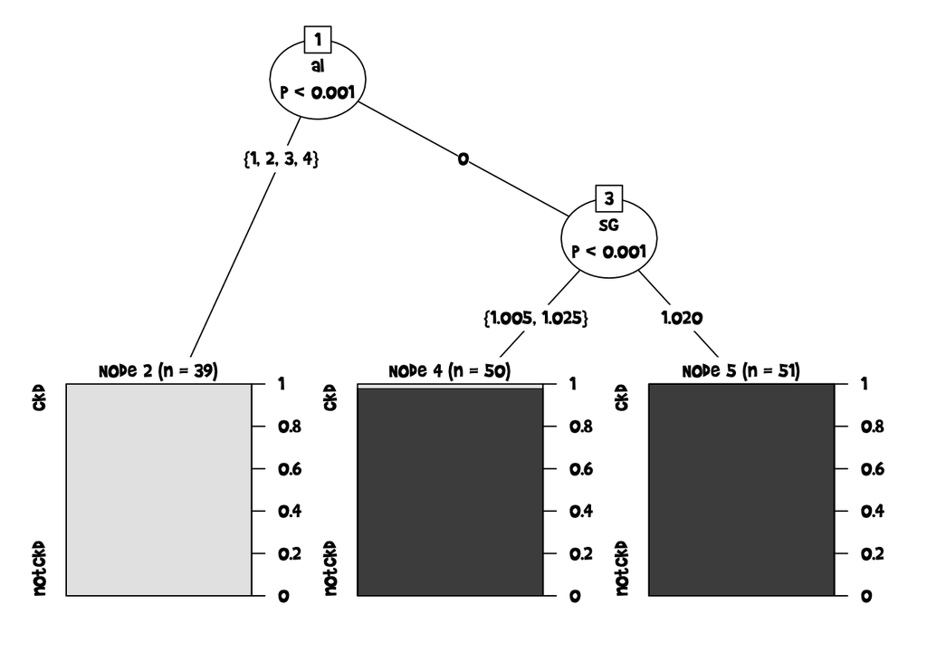

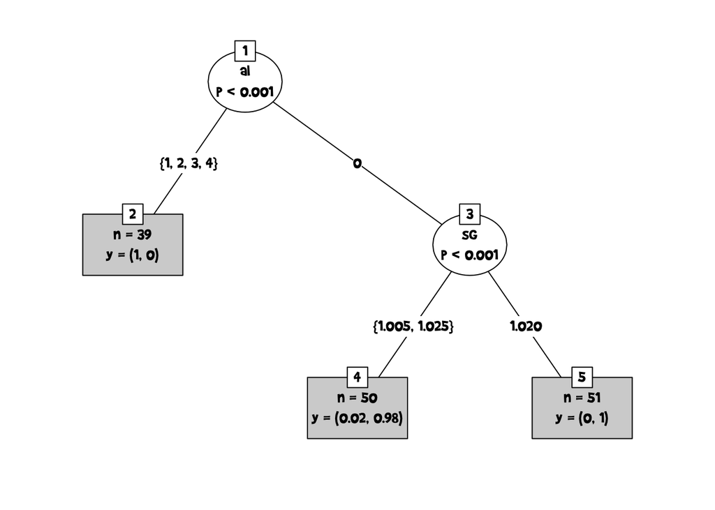

```
## Confusion Matrix and Statistics
##
##
## testPred1 ckd notckd
##    ckd      3      0
##    notckd   0     15
##
##                Accuracy : 1
##                  95% CI : (0.8147, 1)
##     No Information Rate : 0.8333
##     P-Value [Acc > NIR] : 0.03756
##
##                   Kappa : 1
##
##  Mcnemar's Test P-Value : NA
##
##             Sensitivity : 1.0000
##             Specificity : 1.0000
##          Pos Pred Value : 1.0000
##          Neg Pred Value : 1.0000
##              Prevalence : 0.1667
##          Detection Rate : 0.1667
##    Detection Prevalence : 0.1667
##       Balanced Accuracy : 1.0000
##
##        'Positive' Class : ckd
##
```

### RS 80:20

```
##
##          ckd notckd
##   ckd     33      0
##   notckd   1     98
```

```
##
##   Conditional inference tree with 3 terminal nodes
##
## Response:  class
## Inputs:  age, bp, sg, al, su, rbc, pc, pcc, ba, bgr, sod, pot, wc, rc, htn, dm, cad, appet, pe, ane
## Number of observations:  132
##
## 1) al == {1, 2, 3, 4}; criterion = 1, statistic = 125.863
##   2)*  weights = 33
## 1) al == {0}
##   3) sg == {1.005, 1.025}; criterion = 1, statistic = 98
##     4)*  weights = 49
##   3) sg == {1.020}
##     5)*  weights = 50
```

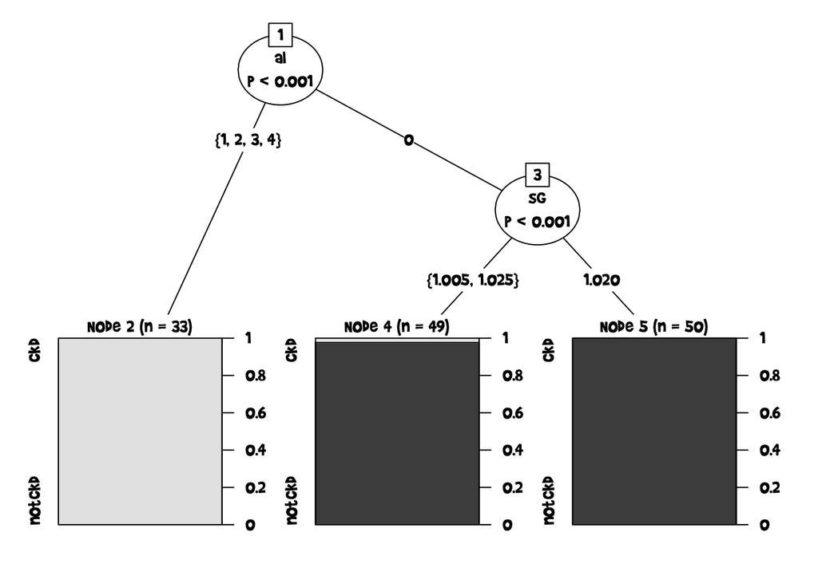

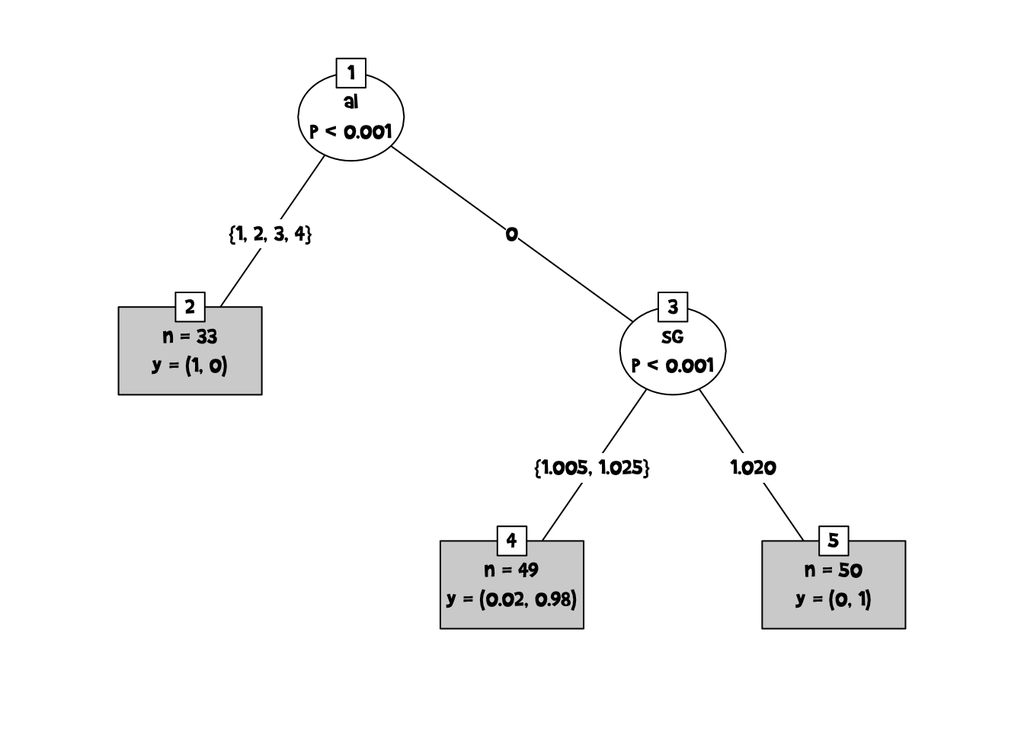

```
## Confusion Matrix and Statistics
##
##
## testPred2 ckd notckd
##    ckd      9      0
##    notckd   0     17
##
##                Accuracy : 1
##                  95% CI : (0.8677, 1)
##     No Information Rate : 0.6538
##     P-Value [Acc > NIR] : 1.594e-05
##
##                   Kappa : 1
##
##  Mcnemar's Test P-Value : NA
##
##             Sensitivity : 1.0000
##             Specificity : 1.0000
##          Pos Pred Value : 1.0000
##          Neg Pred Value : 1.0000
##              Prevalence : 0.3462
##          Detection Rate : 0.3462
##    Detection Prevalence : 0.3462
##       Balanced Accuracy : 1.0000
##
##        'Positive' Class : ckd
##
```

### RS 70:30

```
##
##          ckd notckd
##   ckd     27      0
##   notckd   1     77
```

```
##
##   Conditional inference tree with 2 terminal nodes
##
## Response:  class
## Inputs:  age, bp, sg, al, su, rbc, pc, pcc, ba, bgr, sod, pot, wc, rc, htn, dm, cad, appet, pe, ane
## Number of observations:  105
##
## 1) al == {1, 2, 3, 4}; criterion = 1, statistic = 99
##   2)*  weights = 27
## 1) al == {0}
##   3)*  weights = 78
```

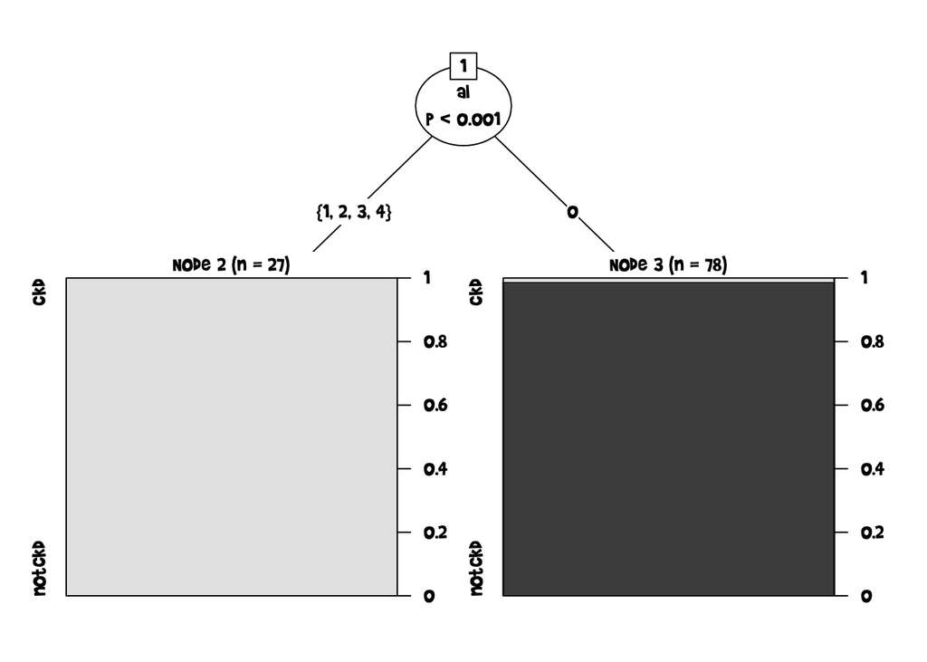

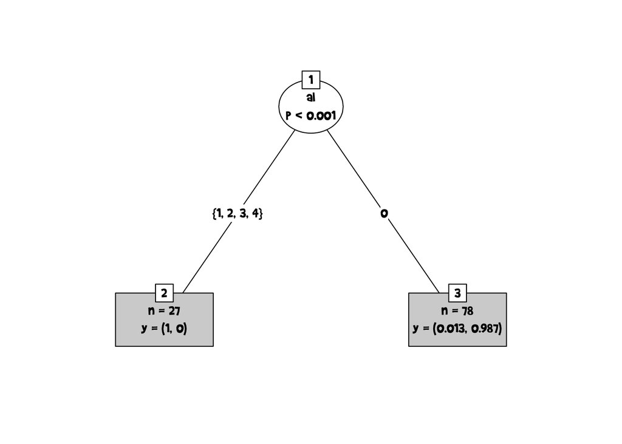

```
## Confusion Matrix and Statistics
##
##
## testPred3 ckd notckd
##    ckd     15      0
##    notckd   0     38
##
##                Accuracy : 1
##                  95% CI : (0.9328, 1)
##     No Information Rate : 0.717
##     P-Value [Acc > NIR] : 2.197e-08
##
##                   Kappa : 1
##
##  Mcnemar's Test P-Value : NA
##
##             Sensitivity : 1.000
##             Specificity : 1.000
##          Pos Pred Value : 1.000
##          Neg Pred Value : 1.000
##              Prevalence : 0.283
##          Detection Rate : 0.283
##    Detection Prevalence : 0.283
##       Balanced Accuracy : 1.000
##
##        'Positive' Class : ckd
##
```

## naive Bayes

### nB (všeobecnejši prípad)

```r
NB_model1 <- naiveBayes(class ~ dm  + sod + ane, data = train1.data)
NB_pred1 <- predict(NB_model1,test1.data)
nbtab1 <- table(NB_pred1, test1.data$class)
print(nbtab1)
```

```
##
## NB_pred1 ckd notckd
##   ckd      2      0
##   notckd   1     15
```

```r
confusionMatrix(nbtab1)
```

```
## Confusion Matrix and Statistics
##
##
## NB_pred1 ckd notckd
##   ckd      2      0
##   notckd   1     15
##
##                Accuracy : 0.9444
##                  95% CI : (0.7271, 0.9986)
##     No Information Rate : 0.8333
##     P-Value [Acc > NIR] : 0.1728
##
##                   Kappa : 0.7692
##
##  Mcnemar's Test P-Value : 1.0000
##
##             Sensitivity : 0.6667
##             Specificity : 1.0000
##          Pos Pred Value : 1.0000
##          Neg Pred Value : 0.9375
##              Prevalence : 0.1667
##          Detection Rate : 0.1111
##    Detection Prevalence : 0.1111
##       Balanced Accuracy : 0.8333
##
##        'Positive' Class : ckd
##
```

### nB 90:10

```r
NB_model1 <- naiveBayes(class ~ ., data = train1.data)
NB_pred1 <- predict(NB_model1,test1.data)
nbtab1 <- table(NB_pred1, test1.data$class)
print(nbtab1)
```

```
##
## NB_pred1 ckd notckd
##   ckd      3      0
##   notckd   0     15
```

```r
confusionMatrix(nbtab1)
```

```
## Confusion Matrix and Statistics
##
##
## NB_pred1 ckd notckd
##   ckd      3      0
##   notckd   0     15
##
##                Accuracy : 1
##                  95% CI : (0.8147, 1)
##     No Information Rate : 0.8333
##     P-Value [Acc > NIR] : 0.03756
##
##                   Kappa : 1
##
##  Mcnemar's Test P-Value : NA
##
##             Sensitivity : 1.0000
##             Specificity : 1.0000
##          Pos Pred Value : 1.0000
##          Neg Pred Value : 1.0000
##              Prevalence : 0.1667
##          Detection Rate : 0.1667
##    Detection Prevalence : 0.1667
##       Balanced Accuracy : 1.0000
##
##        'Positive' Class : ckd
##
```

### nB 80:20

```r
NB_model2 <- naiveBayes(class ~ ., data = train2.data)
NB_pred2 <- predict(NB_model2,test2.data)
nbtab2 <- table(NB_pred2, test2.data$class)
print(nbtab2)
```

```
##
## NB_pred2 ckd notckd
##   ckd      9      0
##   notckd   0     17
```

```r
confusionMatrix(nbtab2)
```

```
## Confusion Matrix and Statistics
##
##
## NB_pred2 ckd notckd
##   ckd      9      0
##   notckd   0     17
##
##                Accuracy : 1
##                  95% CI : (0.8677, 1)
##     No Information Rate : 0.6538
##     P-Value [Acc > NIR] : 1.594e-05
##
##                   Kappa : 1
##
##  Mcnemar's Test P-Value : NA
##
##             Sensitivity : 1.0000
##             Specificity : 1.0000
##          Pos Pred Value : 1.0000
##          Neg Pred Value : 1.0000
##              Prevalence : 0.3462
##          Detection Rate : 0.3462
##    Detection Prevalence : 0.3462
##       Balanced Accuracy : 1.0000
##
##        'Positive' Class : ckd
##
```

### nB 70:30

```r
NB_model3 <- naiveBayes(class ~ ., data = train3.data)
NB_pred3 <- predict(NB_model3,test3.data)
nbtab3 <- table(NB_pred3, test3.data$class)
print(nbtab1)
```

```
##
## NB_pred1 ckd notckd
##   ckd      3      0
##   notckd   0     15
```

```r
confusionMatrix(nbtab3)
```

```
## Confusion Matrix and Statistics
##
##
## NB_pred3 ckd notckd
##   ckd     15      0
##   notckd   0     38
##
##                Accuracy : 1
##                  95% CI : (0.9328, 1)
##     No Information Rate : 0.717
##     P-Value [Acc > NIR] : 2.197e-08
##
##                   Kappa : 1
##
##  Mcnemar's Test P-Value : NA
##
##             Sensitivity : 1.000
##             Specificity : 1.000
##          Pos Pred Value : 1.000
##          Neg Pred Value : 1.000
##              Prevalence : 0.283
##          Detection Rate : 0.283
##    Detection Prevalence : 0.283
##       Balanced Accuracy : 1.000
##
##        'Positive' Class : ckd
##
```

## Tabuľka presností metód

| Klasifikátor | 90:10% | 80:20% | 70:30% |
| --- | --- | --- | --- |
| Rozhodovaci strom | 100 | 100 | 100 |
| naive Bayes | 100 | 100 | 100 |

## kNN

### Trenovacia a testovacia množina

```r
library(class)
set.seed(1234)

knn.training1 <- train1.data[,c(1:20)]
knn.test1 <- test1.data[,c(1:20)]
knn.trainLabel1 <- train1.data[,c(21)]
knn.testLabel1 <-test1.data[,c(21)]

knn.training2 <- train2.data[,c(1:20)]
knn.test2 <- test2.data[,c(1:20)]
knn.trainLabel2 <- train2.data[,c(21)]
knn.testLabel2 <-test2.data[,c(21)]

knn.training3 <- train3.data[,c(1:20)]
knn.test3 <- test3.data[,c(1:20)]
knn.trainLabel3 <- train3.data[,c(21)]
knn.testLabel3 <-test3.data[,c(21)]
```

#### Úprava nových atribútov

```
##       age              bp             sg     al      su
##  Min.   : 6.00   Min.   : 60.00   1.005: 3   0:101   0:123
##  1st Qu.:40.75   1st Qu.: 67.50   1.010:20   1:  3   1:  6
##  Median :50.00   Median : 80.00   1.015:10   2:  8   2:  5
##  Mean   :49.49   Mean   : 74.21   1.020:55   3: 14   3:  3
##  3rd Qu.:60.00   3rd Qu.: 80.00   1.025:52   4: 14   4:  2
##  Max.   :83.00   Max.   :110.00              5:  0   5:  1
##        rbc             pc              pcc               ba
##  abnormal: 18   abnormal: 27   notpresent:127   notpresent:130
##  normal  :122   normal  :113   present   : 13   present   : 10
##
##
##
##
##       bgr             sod             pot               wc
##  Min.   : 70.0   Min.   :111.0   Min.   : 2.500   Min.   : 3800
##  1st Qu.: 97.0   1st Qu.:135.0   1st Qu.: 3.800   1st Qu.: 6675
##  Median :117.0   Median :139.0   Median : 4.600   Median : 7900
##  Mean   :133.1   Mean   :138.7   Mean   : 4.736   Mean   : 8563
##  3rd Qu.:132.0   3rd Qu.:144.0   3rd Qu.: 4.925   3rd Qu.: 9800
##  Max.   :490.0   Max.   :150.0   Max.   :47.000   Max.   :26400
##        rc         htn        dm       cad       appet       pe
##  Min.   :2.100   no :107   no :113   no :130   good:121   no :121
##  1st Qu.:4.300   yes: 33   yes: 27   yes: 10   poor: 19   yes: 19
##  Median :4.900
##  Mean   :4.853
##  3rd Qu.:5.600
##  Max.   :8.000
##   ane
##  no :125
##  yes: 15
##
##
##
##
```

### kNN 90:10

```r
knn.pred1_3<-knn(train = knn.training1, test = knn.test1, cl = knn.trainLabel1, k = 3)
confusionMatrix(knn.pred1_3,knn.testLabel1)
```

```
## Confusion Matrix and Statistics
##
##           Reference
## Prediction  0  1
##          0  3  0
##          1  0 15
##
##                Accuracy : 1
##                  95% CI : (0.8147, 1)
##     No Information Rate : 0.8333
##     P-Value [Acc > NIR] : 0.03756
##
##                   Kappa : 1
##
##  Mcnemar's Test P-Value : NA
##
##             Sensitivity : 1.0000
##             Specificity : 1.0000
##          Pos Pred Value : 1.0000
##          Neg Pred Value : 1.0000
##              Prevalence : 0.1667
##          Detection Rate : 0.1667
##    Detection Prevalence : 0.1667
##       Balanced Accuracy : 1.0000
##
##        'Positive' Class : 0
##
```

```r
knn.pred1_7<-knn(train = knn.training1, test = knn.test1, cl = knn.trainLabel1, k = 7)
confusionMatrix(knn.pred1_7,knn.testLabel1)
```

```
## Confusion Matrix and Statistics
##
##           Reference
## Prediction  0  1
##          0  2  0
##          1  1 15
##
##                Accuracy : 0.9444
##                  95% CI : (0.7271, 0.9986)
##     No Information Rate : 0.8333
##     P-Value [Acc > NIR] : 0.1728
##
##                   Kappa : 0.7692
##
##  Mcnemar's Test P-Value : 1.0000
##
##             Sensitivity : 0.6667
##             Specificity : 1.0000
##          Pos Pred Value : 1.0000
##          Neg Pred Value : 0.9375
##              Prevalence : 0.1667
##          Detection Rate : 0.1111
##    Detection Prevalence : 0.1111
##       Balanced Accuracy : 0.8333
##
##        'Positive' Class : 0
##
```

```r
knn.pred1_10<-knn(train = knn.training1, test = knn.test1, cl = knn.trainLabel1, k = 10)
confusionMatrix(knn.pred1_10,knn.testLabel1)
```

```
## Confusion Matrix and Statistics
##
##           Reference
## Prediction  0  1
##          0  2  0
##          1  1 15
##
##                Accuracy : 0.9444
##                  95% CI : (0.7271, 0.9986)
##     No Information Rate : 0.8333
##     P-Value [Acc > NIR] : 0.1728
##
##                   Kappa : 0.7692
##
##  Mcnemar's Test P-Value : 1.0000
##
##             Sensitivity : 0.6667
##             Specificity : 1.0000
##          Pos Pred Value : 1.0000
##          Neg Pred Value : 0.9375
##              Prevalence : 0.1667
##          Detection Rate : 0.1111
##    Detection Prevalence : 0.1111
##       Balanced Accuracy : 0.8333
##
##        'Positive' Class : 0
##
```

### kNN 80:20

```r
knn.pred2_3<-knn(train = knn.training2, test = knn.test2, cl = knn.trainLabel2, k = 3)
confusionMatrix(knn.pred2_3,knn.testLabel2)
```

```
## Confusion Matrix and Statistics
##
##           Reference
## Prediction  0  1
##          0  4  0
##          1  5 17
##
##                Accuracy : 0.8077
##                  95% CI : (0.6065, 0.9345)
##     No Information Rate : 0.6538
##     P-Value [Acc > NIR] : 0.07014
##
##                   Kappa : 0.5113
##
##  Mcnemar's Test P-Value : 0.07364
##
##             Sensitivity : 0.4444
##             Specificity : 1.0000
##          Pos Pred Value : 1.0000
##          Neg Pred Value : 0.7727
##              Prevalence : 0.3462
##          Detection Rate : 0.1538
##    Detection Prevalence : 0.1538
##       Balanced Accuracy : 0.7222
##
##        'Positive' Class : 0
##
```

```r
knn.pred2_7<-knn(train = knn.training2, test = knn.test2, cl = knn.trainLabel2, k = 7)
confusionMatrix(knn.pred2_7,knn.testLabel2)
```

```
## Confusion Matrix and Statistics
##
##           Reference
## Prediction  0  1
##          0  4  0
##          1  5 17
##
##                Accuracy : 0.8077
##                  95% CI : (0.6065, 0.9345)
##     No Information Rate : 0.6538
##     P-Value [Acc > NIR] : 0.07014
##
##                   Kappa : 0.5113
##
##  Mcnemar's Test P-Value : 0.07364
##
##             Sensitivity : 0.4444
##             Specificity : 1.0000
##          Pos Pred Value : 1.0000
##          Neg Pred Value : 0.7727
##              Prevalence : 0.3462
##          Detection Rate : 0.1538
##    Detection Prevalence : 0.1538
##       Balanced Accuracy : 0.7222
##
##        'Positive' Class : 0
##
```

```r
knn.pred2_10<-knn(train = knn.training2, test = knn.test2, cl = knn.trainLabel2, k = 10)
confusionMatrix(knn.pred2_10,knn.testLabel2)
```

```
## Confusion Matrix and Statistics
##
##           Reference
## Prediction  0  1
##          0  4  0
##          1  5 17
##
##                Accuracy : 0.8077
##                  95% CI : (0.6065, 0.9345)
##     No Information Rate : 0.6538
##     P-Value [Acc > NIR] : 0.07014
##
##                   Kappa : 0.5113
##
##  Mcnemar's Test P-Value : 0.07364
##
##             Sensitivity : 0.4444
##             Specificity : 1.0000
##          Pos Pred Value : 1.0000
##          Neg Pred Value : 0.7727
##              Prevalence : 0.3462
##          Detection Rate : 0.1538
##    Detection Prevalence : 0.1538
##       Balanced Accuracy : 0.7222
##
##        'Positive' Class : 0
##
```

### kNN 70:30

```r
knn.pred3_3<-knn(train = knn.training3, test = knn.test3, cl = knn.trainLabel3, k = 3)
confusionMatrix(knn.pred3_3,knn.testLabel3)
```

```
## Confusion Matrix and Statistics
##
##           Reference
## Prediction  0  1
##          0  6  0
##          1  9 38
##
##                Accuracy : 0.8302
##                  95% CI : (0.702, 0.9193)
##     No Information Rate : 0.717
##     P-Value [Acc > NIR] : 0.041904
##
##                   Kappa : 0.4887
##
##  Mcnemar's Test P-Value : 0.007661
##
##             Sensitivity : 0.4000
##             Specificity : 1.0000
##          Pos Pred Value : 1.0000
##          Neg Pred Value : 0.8085
##              Prevalence : 0.2830
##          Detection Rate : 0.1132
##    Detection Prevalence : 0.1132
##       Balanced Accuracy : 0.7000
##
##        'Positive' Class : 0
##
```

```r
knn.pred3_7<-knn(train = knn.training3, test = knn.test3, cl = knn.trainLabel3, k = 7)
confusionMatrix(knn.pred3_7,knn.testLabel3)
```

```
## Confusion Matrix and Statistics
##
##           Reference
## Prediction  0  1
##          0  5  0
##          1 10 38
##
##                Accuracy : 0.8113
##                  95% CI : (0.6803, 0.9056)
##     No Information Rate : 0.717
##     P-Value [Acc > NIR] : 0.081259
##
##                   Kappa : 0.4176
##
##  Mcnemar's Test P-Value : 0.004427
##
##             Sensitivity : 0.33333
##             Specificity : 1.00000
##          Pos Pred Value : 1.00000
##          Neg Pred Value : 0.79167
##              Prevalence : 0.28302
##          Detection Rate : 0.09434
##    Detection Prevalence : 0.09434
##       Balanced Accuracy : 0.66667
##
##        'Positive' Class : 0
##
```

```r
knn.pred3_10<-knn(train = knn.training3, test = knn.test3, cl = knn.trainLabel3, k = 10)
confusionMatrix(knn.pred3_10,knn.testLabel3)
```

```
## Confusion Matrix and Statistics
##
##           Reference
## Prediction  0  1
##          0  3  0
##          1 12 38
##
##                Accuracy : 0.7736
##                  95% CI : (0.6379, 0.8772)
##     No Information Rate : 0.717
##     P-Value [Acc > NIR] : 0.225885
##
##                   Kappa : 0.2639
##
##  Mcnemar's Test P-Value : 0.001496
##
##             Sensitivity : 0.2000
##             Specificity : 1.0000
##          Pos Pred Value : 1.0000
##          Neg Pred Value : 0.7600
##              Prevalence : 0.2830
##          Detection Rate : 0.0566
##    Detection Prevalence : 0.0566
##       Balanced Accuracy : 0.6000
##
##        'Positive' Class : 0
##
```

```r
ckd.model2 = ckd.model
levels(ckd.model2$rbc) = c("0","1")
levels(ckd.model2$pc) = c("0","1")
levels(ckd.model2$pcc) = c("0","1")
levels(ckd.model2$ba) = c("0","1")
levels(ckd.model2$htn) = c("0","1")
levels(ckd.model2$dm) = c("0","1")
levels(ckd.model2$cad) = c("0","1")
levels(ckd.model2$appet) = c("0","1")
levels(ckd.model2$pe) = c("0","1")
levels(ckd.model2$ane) = c("0","1")
```

## Zhlukovanie

```r
ckd.model2$class <- NULL
kmeans.result <- kmeans(ckd.model2, 2)
table(ckd.model$class, kmeans.result$cluster)
```

```
##
##           1  2
##   ckd    18 25
##   notckd 78 37
```

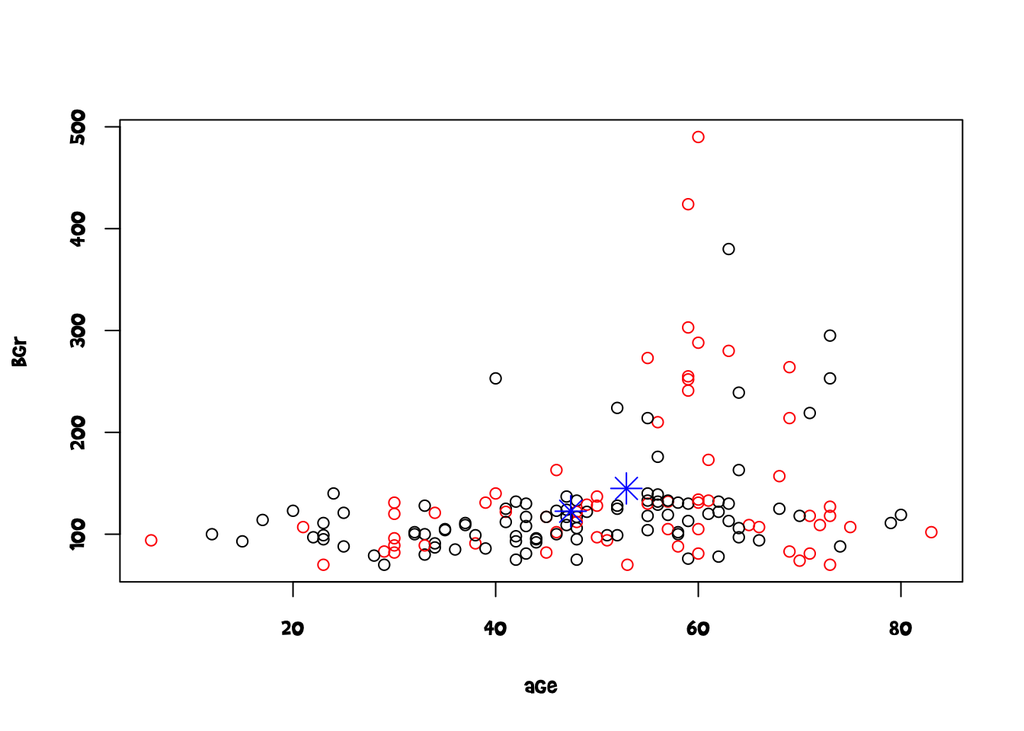

```r
plot(ckd.model2[c("age","bgr")], col=kmeans.result$cluster)
points(kmeans.result$centers[,c("age",
                                "bgr")], col = "blue" , pch = 8, cex = 2)
```

## Vyhodnotenie

- Rouhodovacie stromy nadobudli pre všetky množiny presnosť 100% a to z dôvodu že mode používal silné atribúty resp. atribúty na základe ktorých sa vedel presne rozhodnúť.
- Pri naive Bayess boli výsledký rovnaké a model taktiež nadobúdal 100% presnosť. Z tejto analýzy taktiež vyplynulo, že vačšina chorých bola vo veku od 4O rokov a mali byť vysoký krvný tlak alebo diabetes(cukrovku).